# Aplicación de HMM

### 1.- Importar set de datos y realizar Análisis Exploratorio.

Se importa el set de datos, seleccionando el rango de cantidad de caracteres a trabajar (114 a 170 en este experimento), para luego efectuar boxplot comparativo:

```r
dat=read.csv("SMSSpamCollection(cod3).csv",sep=";")
head(dat)
```

```
##   resultado
## 1       ham
## 2       ham
## 3      spam
## 4       ham
## 5       ham
## 6      spam
##                                                                                                                                                       mensaje
## 1                                             Go until jurong point, crazy.. Available only in bugis n great world la e buffet... Cine there got amore wat...
## 2                                                                                                                               Ok lar... Joking wif u oni...
## 3 Free entry in 2 a wkly comp to win FA Cup final tkts 21st May 2005. Text FA to 87121 to receive entry question(std txt rate)T&C's apply 08452810075over18's
## 4                                                                                                           U dun say so early hor... U c already then say...
## 5                                                                                               Nah I don't think he goes to usf, he lives around here though
## 6        FreeMsg Hey there darling it's been 3 week's now and no word back! I'd like some fun you up for it still? Tb ok! XxX std chgs to send, ¬£1.50 to rcv
##   largo
## 1   111
## 2    29
## 3   155
## 4    49
## 5    61
## 6   148
```

```r
names(dat)
```

```
## [1] "resultado" "mensaje"   "largo"
```

```r
#largo entre 114 y 170 caracteres: muestra total = 1290
dat=dat[dat$largo>=114 & dat$largo<=170,]
dim(dat)
```

```
## [1] 1290    3
```

```r
#AED cantidad de caracteres del mensaje:
library("ggpubr")
str(dat)
```

```
## 'data.frame':    1290 obs. of  3 variables:
##  $ resultado: chr  "spam" "spam" "ham" "spam" ...
##  $ mensaje  : chr  "Free entry in 2 a wkly comp to win FA Cup final tkts 21st May 2005. Text FA to 87121 to receive entry question("| __truncated__ "FreeMsg Hey there darling it's been 3 week's now and no word back! I'd like some fun you up for it still? Tb ok"| __truncated__ "As per your request…
##  $ largo    : int  155 148 160 158 154 136 156 149 156 144 ...
```

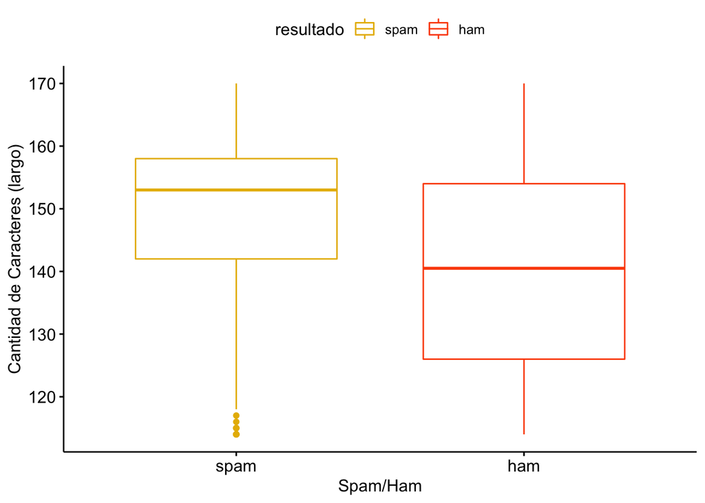

```r
dat$resultado=as.factor(dat$resultado)
ggboxplot(dat, x = "resultado", y = "largo",
          color = "resultado", palette = c("#E7B800", "#FC4E07"),
          order = c("spam","ham"),
          ylab = "Cantidad de Caracteres (largo)", xlab = "Spam/Ham")
```

Se estudia existencia de diferencias significativas, empleando prueba no paramétrica de Wilcoxon, que compara medianas. Esto debido a que, como se puede ver a través del test de Lilliefors implementado, la variable numérica en ninguno de los grupos puede describirse mediante una distribución Normal.

```r
#existencia de diferencias significativas:
table(dat$resultado)
```

```
##
##  ham spam
##  668  622
```

```r
library(nortest)
lillie.test(dat$largo[dat$resultado=="ham"])    #rechaza.
```

```
##
##  Lilliefors (Kolmogorov-Smirnov) normality test
##
## data:  dat$largo[dat$resultado == "ham"]
## D = 0.094574, p-value = 1.429e-15
```

```r
lillie.test(dat$largo[dat$resultado=="spam"])   #rechaza.
```

```
##
##  Lilliefors (Kolmogorov-Smirnov) normality test
##
## data:  dat$largo[dat$resultado == "spam"]
## D = 0.14722, p-value < 2.2e-16
```

```r
wilcox.test(dat$largo~dat$resultado)            #rechaza igualdad de medianas. Existen diferencias significativas.
```

```
##
##  Wilcoxon rank sum test with continuity correction
##
## data:  dat$largo by dat$resultado
## W = 134070, p-value < 2.2e-16
## alternative hypothesis: true location shift is not equal to 0
```

### 2.- Naive Bayes

Se separa la muestra en training y test (70% - 30%), respetando secuencialidad para aplicar HMM. Luego se observan los resultados de la técnica de clasificación de Naive Bayes, a través de su matriz de confusión.

La implementación de Naive Bayes se encuentra disponible en la librería *e1071*.

```r
#division de la muestra en training y test:
dim(dat)
```

```
## [1] 1290    3
```

```r
sample2=rep(c(TRUE, FALSE), c(913,1290-913))
entrenamiento2=dat[sample2, ]
prueba2=dat[!sample2, ]

#comparaciones de las bases:
table(entrenamiento2$resultado)/nrow(entrenamiento2)
```

```
##
##       ham      spam
## 0.5235487 0.4764513
```

```r
table(prueba2$resultado)/nrow(prueba2)
```

```
##
##       ham      spam
## 0.5039788 0.4960212
```

```r
#Naive Bayes:
#install.packages("e1071")
#install.packages("caTools")
#install.packages("caret")

library(e1071)
library(caTools)
library(caret)
nb2 = naiveBayes(resultado ~ largo, data = entrenamiento2)
nb2
```

```
##
## Naive Bayes Classifier for Discrete Predictors
##
## Call:
## naiveBayes.default(x = X, y = Y, laplace = laplace)
##
## A-priori probabilities:
## Y
##       ham      spam
## 0.5235487 0.4764513
##
## Conditional probabilities:
##       largo
## Y          [,1]     [,2]
##   ham  139.1527 15.41854
##   spam 148.9425 12.14122
```

```r
#prediccion
prediccion2=predict(nb2, newdata = prueba2)

#matriz de confusion
mc2=table(prueba2$resultado, prediccion2)
mc2
```

```
##       prediccion2
##        ham spam
##   ham   98   92
##   spam  50  137
```

```r
#evaluacion general
confusionMatrix(mc2)
```

```
## Confusion Matrix and Statistics
##
##       prediccion2
##        ham spam
##   ham   98   92
##   spam  50  137
##
##                Accuracy : 0.6233
##                  95% CI : (0.5723, 0.6724)
##     No Information Rate : 0.6074
##     P-Value [Acc > NIR] : 0.2818083
##
##                   Kappa : 0.248
##
##  Mcnemar's Test P-Value : 0.0005803
##
##             Sensitivity : 0.6622
##             Specificity : 0.5983
##          Pos Pred Value : 0.5158
##          Neg Pred Value : 0.7326
##              Prevalence : 0.3926
##          Detection Rate : 0.2599
##    Detection Prevalence : 0.5040
##       Balanced Accuracy : 0.6302
##
##        'Positive' Class : ham
##
```

### 3.- Regresión Logística

Con la muestra separada en training y test (70% - 30%), se observan los resultados de la técnica de clasificación de Regresión Logística, a través de su matriz de confusión. El formato del resultado final (matriz de confusión) puede diferir, de modo que en la construcción de la tabla de métricas, presente en el reporte y presentación, se debe calcular poniendo atención a qué celdas corresponden a TP, FP, TN y FN.

En este caso, la categoría “spam” corresponde a 1 y “ham” (mensajes legítimos), a 0.

```r
str(entrenamiento2)
```

```
## 'data.frame':    913 obs. of  3 variables:
##  $ resultado: Factor w/ 2 levels "ham","spam": 2 2 1 2 2 2 2 2 2 1 ...
##  $ mensaje  : chr  "Free entry in 2 a wkly comp to win FA Cup final tkts 21st May 2005. Text FA to 87121 to receive entry question("| __truncated__ "FreeMsg Hey there darling it's been 3 week's now and no word back! I'd like some fun you up for it still? Tb ok"| __truncated__ "As per your request…
##  $ largo    : int  155 148 160 158 154 136 156 149 156 144 ...
```

```r
entrenamiento2$resultado2=ifelse(entrenamiento2$resultado=="spam",1,0)
entrenamiento2$resultado2=factor(entrenamiento2$resultado2)
modeloRL2=glm(resultado2~largo, family=binomial(link="logit"), data=entrenamiento2)
summary(modeloRL2)
```

```
##
## Call:
## glm(formula = resultado2 ~ largo, family = binomial(link = "logit"),
##     data = entrenamiento2)
##
## Deviance Residuals:
##    Min      1Q  Median      3Q     Max
## -1.695  -1.070  -0.625   1.041   1.881
##
## Coefficients:
##              Estimate Std. Error z value Pr(>|z|)
## (Intercept) -7.177142   0.745247  -9.631   <2e-16 ***
## largo        0.049071   0.005114   9.595   <2e-16 ***
## ---
## Signif. codes:  0 '***' 0.001 '**' 0.01 '*' 0.05 '.' 0.1 ' ' 1
##
## (Dispersion parameter for binomial family taken to be 1)
##
##     Null deviance: 1263.7  on 912  degrees of freedom
## Residual deviance: 1159.0  on 911  degrees of freedom
## AIC: 1163
##
## Number of Fisher Scoring iterations: 4
```

```r
library(caret)
prueba2$resultado2=ifelse(prueba2$resultado=="spam",1,0)
prueba2$resultado2=factor(prueba2$resultado2)
phat2=predict(modeloRL2, newdata=prueba2, type="response")
veredicto2 = ifelse(phat2 > 0.5, 1, 0)
veredicto2 = factor(veredicto2, levels=levels(prueba2$resultado2))
confusionMatrix(veredicto2,prueba2$resultado2)
```

```
## Confusion Matrix and Statistics
##
##           Reference
## Prediction   0   1
##          0 106  72
##          1  84 115
##
##                Accuracy : 0.5862
##                  95% CI : (0.5346, 0.6364)
##     No Information Rate : 0.504
##     P-Value [Acc > NIR] : 0.0008186
##
##                   Kappa : 0.1728
##
##  Mcnemar's Test P-Value : 0.3784776
##
##             Sensitivity : 0.5579
##             Specificity : 0.6150
##          Pos Pred Value : 0.5955
##          Neg Pred Value : 0.5779
##              Prevalence : 0.5040
##          Detection Rate : 0.2812
##    Detection Prevalence : 0.4721
##       Balanced Accuracy : 0.5864
##
##        'Positive' Class : 0
##
```

### 4.- HMM

En primer lugar, se implementan los algoritmos de acuerdo con lo presentado por Coelho et al. (2019). En esta referencia se pueden encontrar códigos propuestos para Matlab.

Cabe señalar que la implementación base que presenta el texto para el algoritmo de Baum-Welch exhibirá inestabilidad numérica (se deben normalizar algunas probabilidades involucradas). No obstante, esto no sucederá con el algoritmo de Viterbi para el problema de decodificación (clasificación), ya que la normalización requerida fue incorporada.

```r
#1.- Forward Algorithm
#---------------------

forward=function(A,B,O,c){
  #m estados ocultos, n estados observables, N observaciones
  #A: mxm (matriz de transicion)
  #B: mxn (matriz de emisiones)
  #O: 1xN (vector de observaciones)
  #c: 1xm (vector de probabilidades iniciales)

  m=nrow(B)
  n=ncol(B)
  N=length(O)
  Alpha=matrix(0,nrow=N,ncol=m)

  #Inicializacion:
  for (k in 1:m){
    Alpha[1,k]=c[k]*B[k,O[1]]
    #Nota: requiere que los estados observados esten relacionados
    #en orden con las columnas de la matriz B.
  }

  #Recursion:
  for (l in 2:N){
    for (k in 1:m){
      S=0
      for (i in 1:m){
        S=S+A[i,k]*Alpha[l-1,i]
      }
      Alpha[l,k]=B[k,O[l]]*S
    }
  }

  #Probabilidad de observar la secuencia:
  #Nota: en este caso interesa la ultima fila.
  P=sum(Alpha[N,])

  return(P)
}


#Variacion para que retorne la matriz Alpha:
#-------------------------------------------

forward_matriz=function(A,B,O,c){
  #m estados ocultos, n estados observables, N observaciones
  #A: mxm (matriz de transicion)
  #B: mxn (matriz de emisiones)
  #O: 1xN (vector de observaciones)
  #c: 1xm (vector de probabilidades iniciales)

  m=nrow(B)
  n=ncol(B)
  N=length(O)
  Alpha=matrix(0,nrow=N,ncol=m)

  #Inicializacion:
  for (k in 1:m){
    Alpha[1,k]=c[k]*B[k,O[1]]
    #Nota: requiere que los estados observados esten relacionados
    #en orden con las columnas de la matriz B.
  }

  #Recursion:
  for (l in 2:N){
    for (k in 1:m){
      S=0
      for (i in 1:m){
        S=S+A[i,k]*Alpha[l-1,i]
      }
      Alpha[l,k]=B[k,O[l]]*S
    }
  }


  return(Alpha)
}


#2.- Backward Algorithm
#----------------------

backward=function(A,B,O){
  #m estados ocultos, n estados observables, N observaciones
  #A: mxm (matriz de transicion)
  #B: mxn (matriz de emisiones)
  #O: 1xN (vector de observaciones)
  #c: 1xm (vector de probabilidades iniciales)

  m=nrow(B)
  n=ncol(B)
  N=length(O)
  Beta=matrix(0,nrow=N,ncol=m)

  #Inicializacion:
  for (k in 1:m){
    Beta[N,k]=1
    #Nota: corresponde a la condición de borde.
  }
  #p=1
  #print(p)

  #Recursion:
  for(t in 1:(N-1)){
    #print("hola")
    #print(t)
    for(i in 1:m){
      Beta[N-t,i]=0
      for(j in 1:m){
        #p=p+1
        #r=N-t+1
        #print(r)
        Beta[N-t,i]=Beta[N-t,i]+A[i,j]*B[j,O[N-t+1]]*Beta[(N-t+1),j]
        #print(p)
        }
    }
  }

  #Esta funcion retorna la matriz completa:
  return(Beta)
}

#3.- Viterbi Algorithm
#---------------------

viterbi=function(A,B,O,c){
  #m estados ocultos, n estados observables, N observaciones
  #A: mxm (matriz de transicion)
  #B: mxn (matriz de emisiones)
  #O: 1xN (vector de observaciones)
  #c: 1xm (vector de probabilidades iniciales)

  m=nrow(B)
  n=ncol(B)
  N=length(O)
  rho=matrix(0,nrow=N,ncol=m)
  rhoprima=rho
  psi=matrix(0,nrow=N,ncol=m)

  #Inicializacion:
  for (k in 1:m){
    #condicion de borde: no hay estados en momento anterior
    psi[1,k]=0
    #condicion de borde para rho:
    rho[1,k]=c[k]*B[k,O[1]]
  }

  #Normalizacion para prevenir numeric underflow:
  for (k in 1:m){
    rhoprima[1,k]=rho[1,k]/sum(rho[1,])
  }


  #Recursion:
  temporal=seq(0,0,length.out = m)
  temporal2=seq(0,0,length.out = m)
  for(k in 2:N){
    for(j in 1:m){
      for(i in 1:m){
        temporal[i]=rho[k-1,i]*A[i,j]*B[j,O[k]]/sum(rho[k-1,])
        temporal2[i]=rho[k-1,i]*A[i,j]/sum(rho[k-1,])
      }
      maximo=max(temporal2)
      rho[k,j]=max(temporal)
      psi[k,j]=which.max(temporal2)
    }
  }

  #Path finding:
  q=seq(0,0,length.out=N)
  q[N]=which.max(rho[N,])
  for(k in 1:(N-1)){
    q[N-k]=psi[N-k+1,q[N-k+1]]
  }
  #print(rho)
  return(q)
}

#2.- Baum-Welch Algorithm
#------------------------

#a) funcion gama:
calcular_gama=function(alfa,beta){
  #alfa: producto de Forward
  #beta: producto de Backward
  N=nrow(alfa)
  m=ncol(alfa)
  gama=alfa
  for(i in 1:N){
    den=0
    for(j in 1:m){
      #gama[i,j]=sum(gama[1:i,j])
      den=den+alfa[i,j]*beta[i,j]
    }
    for(t in 1:m){
      gama[i,t]=alfa[i,t]*beta[i,t]/den
    }
  }
  return(gama)
}

#b) funcion nu:
calcular_nu=function(gama){
  #gama: matriz Nxm
  N=nrow(gama)
  m=ncol(gama)
  nu=gama
  #esta funcion realiza sumatorias sobre gama
  for(i in 1:N){
    for(j in 1:m){
      nu[i,j]=sum(gama[1:i,j])
    }
  }
  return(nu)
}

#c)funcion chi:
calcular_chi=function(alfa,beta,A,B,k,O){
  #Alfa:  del algoritmo forward -> Nxm
  #Beta:  del algoritmo backward -> Nxm
  #A:     matriz de transicion a 1 periodo -> mxm
  #B:     emisiones -> mxn
  #k:     instante en que se esta calculando chi, con k<=N
  #O:     vector de observaciones -> 1xN

  #devolvera una matriz mxm y representa una foto del instante k
  N=nrow(alfa)
  m=ncol(alfa)
  chi=A
  den=0
  for(i in 1:m){
    for(j in 1:m){
      den=den+alfa[k,i]*A[i,j]*B[i,O[k+1]]*beta[k+1,j]
    }
  }
  for(i in 1:m){
    for(j in 1:m){
      chi[i,j]=alfa[k,i]*A[i,j]*B[i,O[k+1]]*beta[k+1,j]/den
    }
  }
  return(chi)
}

#d)funcion tau:
calcular_tau=function(O,alfa,beta,A,B){
  #es una foto para un k fijo

  #O:   vector de observaciones -> 1xN

  m=nrow(A)
  N=length(O)
  tau=matrix(0,nrow=m,ncol=m)
  for(k in 1:(N-1)){
    mat=calcular_chi(alfa,beta,A,B,k,O)
    for(i in 1:m){
      for(j in 1:m){
        tau[i,j]=tau[i,j]+mat[i,j]
      }
    }
  }
  return(tau)
}

#d)funcion taui:
calcular_taui=function(gama){
  #gama:  de la funcion gama -> Nxm

  N=nrow(gama)
  m=ncol(gama)
  taui=seq(0,0,length.out = m)
  for(i in 1:m){
    taui[i]=sum(gama[1:(N-1),i])
  }
  return(taui)
}

#e)funcion omega:
calcular_omega=function(gama,O,B){
  #gama:  de la funcion gama -> Nxm
  #B:     emisiones -> mxn
  #O:     secuencia de observaciones -> 1xN
  #Omega: matriz de mxn (estados x observaciones)
  N=length(O)
  n=ncol(B)
  m=nrow(B)
  omega=matrix(0,nrow=m,ncol=n)
  #for(j in 1:n){
    #posiciones=which(O==j)
    # if(length(posiciones)>0){
    #   omega[,j]=sum(gama[posiciones,])
    # }else{
    #   omega[,j]=0
    # }

  #}
  for(i in 1:m){
    for(j in 1:n){
      for(k in 1:N){
        if(O[k]==j){
          omega[i,j]=omega[i,j]+gama[k,i]
        }else{
          omega[i,j]=omega[i,j]+0
        }
      }
    }
  }
  #print(omega)
  return(omega)
}

#f)Baum-Welch:
bw=function(A,B,O,c,n.iter){
  for(r in 1:n.iter){
  #el algoritmo recibe estimaciones iniciales
  m=nrow(A)
  N=length(O)
  n=ncol(B)
  alfa=forward_matriz(A,B,O,c)
  #print(alfa)
  beta=backward(A,B,O)
  #print(beta)
  gama=calcular_gama(alfa,beta)
  #print(gama)
  tau=calcular_tau(O,alfa,beta,A,B)
  #print(tau)
  taui=calcular_taui(gama)
  #print(taui)
  nu=calcular_nu(gama)
  #print(nu)
  omega=calcular_omega(gama,O,B)

  #salida de parametros
  c_gorro=gama[1,]
  #print(c_gorro)
  A_gorro=matrix(0,nrow=m,ncol=m)
  for(i in 1:m){
    for(j in 1:m){
      A_gorro[i,j]=tau[i,j]/taui[i]
    }
  }
  #print(A_gorro)
  B_gorro=matrix(0,nrow=m,ncol=n)
  for(i in 1:m){
    for(j in 1:n){
      #print(nu[N,i])
      B_gorro[i,j]=omega[i,j]/nu[N,i]
    }
  }
  #print(B_gorro)
  A=A_gorro
  B=B_gorro
  c=c_gorro
  }
  lista=list("Probabilidad inicial"=c_gorro,"Matriz de transicion"=A_gorro,"Matriz de emisiones"=B_gorro)
  return(lista)
}
```

Se divide la muestra en training y test y se estiman los valores iniciales para las matrices: $A$ (matriz de probabilidades de transición); $B$ (matriz de probabilidades de emisión); $c$ (ley de probabilidad inicial). En este punto, se recomienda consultar la notación disponible en el informe que acompaña a este estudio.

```r
#largo entre 114 y 170 caracteres:
dat=read.csv("SMSSpamCollection(cod3).csv",sep=";")
dat=dat[dat$largo>=114 & dat$largo<=170,]
dim(dat)
```

```
## [1] 1290    3
```

```r
table(dat$resultado)/1290
```

```
##
##       ham      spam
## 0.5178295 0.4821705
```

```r
#probabilidad inicial:
initial_distribution = c(0.52,0.48)

#matriz de probabilidades de transicion:
prop.table(table(dat$resultado[1:1289],dat$resultado[2:1290]),1)
```

```
##
##              ham      spam
##   ham  0.4962519 0.5037481
##   spam 0.5418006 0.4581994
```

```r
a=matrix(c(0.5,0.5,0.54,0.46),nrow=2,ncol=2,byrow=T)
a
```

```
##      [,1] [,2]
## [1,] 0.50 0.50
## [2,] 0.54 0.46
```

```r
#matriz de emisiones:
dat$largo_cod=dat$largo-113
dat$resultado_cod=ifelse(dat$resultado=="ham",1,2)
b=prop.table(table(dat$resultado_cod,dat$largo_cod),1)
b=matrix(b,ncol=ncol(b))
b
```

```
##             [,1]        [,2]        [,3]        [,4]        [,5]        [,6]
## [1,] 0.022455090 0.026946108 0.017964072 0.014970060 0.014970060 0.025449102
## [2,] 0.009646302 0.004823151 0.001607717 0.001607717 0.001607717 0.001607717
##            [,7]        [,8]        [,9]       [,10]       [,11]       [,12]
## [1,] 0.01946108 0.026946108 0.017964072 0.014970060 0.010479042 0.022455090
## [2,] 0.01286174 0.006430868 0.008038585 0.003215434 0.006430868 0.001607717
##            [,13]       [,14]       [,15]       [,16]       [,17]       [,18]
## [1,] 0.034431138 0.020958084 0.008982036 0.016467066 0.017964072 0.016467066
## [2,] 0.008038585 0.008038585 0.003215434 0.004823151 0.006430868 0.003215434
##           [,19]       [,20]      [,21]      [,22]      [,23]      [,24]
## [1,] 0.01796407 0.026946108 0.01347305 0.01796407 0.01646707 0.01497006
## [2,] 0.01929260 0.009646302 0.01607717 0.01607717 0.01768489 0.02572347
##            [,25]      [,26]      [,27]       [,28]       [,29]      [,30]
## [1,] 0.016467066 0.01347305 0.01197605 0.017964072 0.023952096 0.01347305
## [2,] 0.006430868 0.01446945 0.01446945 0.009646302 0.009646302 0.02893891
##           [,31]      [,32]      [,33]      [,34]      [,35]      [,36]
## [1,] 0.01497006 0.01197605 0.01347305 0.01946108 0.02395210 0.01946108
## [2,] 0.01929260 0.01929260 0.02250804 0.02733119 0.02090032 0.03376206
##           [,37]      [,38]      [,39]      [,40]      [,41]      [,42]
## [1,] 0.01796407 0.01796407 0.02544910 0.02544910 0.02844311 0.02694611
## [2,] 0.01929260 0.01286174 0.03215434 0.04340836 0.03054662 0.04983923
##           [,43]      [,44]      [,45]      [,46]      [,47]       [,48]
## [1,] 0.02844311 0.02844311 0.02994012 0.03293413 0.02994012 0.004491018
## [2,] 0.05466238 0.04983923 0.05948553 0.06270096 0.05466238 0.040192926
##           [,49]       [,50]       [,51]       [,52]       [,53]       [,54]
## [1,] 0.01197605 0.001497006 0.001497006 0.002994012 0.007485030 0.001497006
## [2,] 0.02411576 0.016077170 0.008038585 0.003215434 0.004823151 0.003215434
##            [,55]       [,56]       [,57]
## [1,] 0.005988024 0.008982036 0.002994012
## [2,] 0.001607717 0.001607717 0.003215434
```

```r
#division de la muestra en training y test, asumiendo secuencialidad de los mensajes:
#proporciones: 70% vs 30% (entrenamiento vs prueba)
#------------------------------------------------------------------------------------

dim(dat)
```

```
## [1] 1290    5
```

```r
sample3=rep(c(TRUE, FALSE), c(913,1290-913))
entrenamiento3=dat[sample3, ]
prueba3=dat[!sample3, ]
```

Para garantizar la estabilidad numérica, se iterará utilizando la implementación del algoritmo Baum-Welch disponible en R (librería *HMM*), mientras que el algoritmo de Viterbi se ejecutará a partir de la implementación realizada según las directrices de Coelho et al. (2019). Se obtiene la matriz de confusión, luego de decodificar, empleando los parámetros obtenidos al iterar con el algoritmo de Baum-Welch.

La nomenclatura en la matriz de confusión puede variar con respecto a los métodos anteriores, de modo que debe analizarse el resultado con precaución, para así efectuar los cálculos posteriores de métricas de desempeño de manera apropiada. Por ejemplo, en este caso los mensajes de la clase “ham” (válidos) corresponden a 1 y “spam”, a 2.

```r
#prueba algoritmo Baum-Welch con libreria HMM:
#=============================================
library(HMM)
hmm = initHMM(c(1,2),1:57,transProbs=a,emissionProbs=b)
print(hmm)
```

```
## $States
## [1] 1 2
##
## $Symbols
##  [1]  1  2  3  4  5  6  7  8  9 10 11 12 13 14 15 16 17 18 19 20 21 22 23 24 25
## [26] 26 27 28 29 30 31 32 33 34 35 36 37 38 39 40 41 42 43 44 45 46 47 48 49 50
## [51] 51 52 53 54 55 56 57
##
## $startProbs
##   1   2
## 0.5 0.5
##
## $transProbs
##     to
## from    1    2
##    1 0.50 0.50
##    2 0.54 0.46
##
## $emissionProbs
##       symbols
## states           1           2           3           4           5           6
##      1 0.022455090 0.026946108 0.017964072 0.014970060 0.014970060 0.025449102
##      2 0.009646302 0.004823151 0.001607717 0.001607717 0.001607717 0.001607717
##       symbols
## states          7           8           9          10          11          12
##      1 0.01946108 0.026946108 0.017964072 0.014970060 0.010479042 0.022455090
##      2 0.01286174 0.006430868 0.008038585 0.003215434 0.006430868 0.001607717
##       symbols
## states          13          14          15          16          17          18
##      1 0.034431138 0.020958084 0.008982036 0.016467066 0.017964072 0.016467066
##      2 0.008038585 0.008038585 0.003215434 0.004823151 0.006430868 0.003215434
##       symbols
## states         19          20         21         22         23         24
##      1 0.01796407 0.026946108 0.01347305 0.01796407 0.01646707 0.01497006
##      2 0.01929260 0.009646302 0.01607717 0.01607717 0.01768489 0.02572347
##       symbols
## states          25         26         27          28          29         30
##      1 0.016467066 0.01347305 0.01197605 0.017964072 0.023952096 0.01347305
##      2 0.006430868 0.01446945 0.01446945 0.009646302 0.009646302 0.02893891
##       symbols
## states         31         32         33         34         35         36
##      1 0.01497006 0.01197605 0.01347305 0.01946108 0.02395210 0.01946108
##      2 0.01929260 0.01929260 0.02250804 0.02733119 0.02090032 0.03376206
##       symbols
## states         37         38         39         40         41         42
##      1 0.01796407 0.01796407 0.02544910 0.02544910 0.02844311 0.02694611
##      2 0.01929260 0.01286174 0.03215434 0.04340836 0.03054662 0.04983923
##       symbols
## states         43         44         45         46         47          48
##      1 0.02844311 0.02844311 0.02994012 0.03293413 0.02994012 0.004491018
##      2 0.05466238 0.04983923 0.05948553 0.06270096 0.05466238 0.040192926
##       symbols
## states         49          50          51          52          53          54
##      1 0.01197605 0.001497006 0.001497006 0.002994012 0.007485030 0.001497006
##      2 0.02411576 0.016077170 0.008038585 0.003215434 0.004823151 0.003215434
##       symbols
## states          55          56          57
##      1 0.005988024 0.008982036 0.002994012
##      2 0.001607717 0.001607717 0.003215434
```

```r
bw = baumWelch(hmm,dat$largo_cod,20)
bw$hmm$startProbs
```

```
##   1   2
## 0.5 0.5
```

```r
bw$hmm$transProbs
```

```
##     to
## from         1         2
##    1 0.4492710 0.5507290
##    2 0.5935561 0.4064439
```

```r
bw$hmm$emissionProbs
```

```
##       symbols
## states          1           2          3           4           5            6
##      1 0.02046996 0.025596541 0.01836548 0.014393333 0.014002435 0.0263418938
##      2 0.01176400 0.006240845 0.00114844 0.002207151 0.002628287 0.0006067774
##       symbols
## states           7           8           9          10          11          12
##      1 0.023918967 0.029433084 0.017985406 0.016121092 0.007405387 0.022369581
##      2 0.008048188 0.003717879 0.007999329 0.001956093 0.009735649 0.001665663
##       symbols
## states          13         14          15          16          17          18
##      1 0.033368176 0.02198025 0.010074482 0.014932892 0.018317126 0.015609192
##      2 0.009140504 0.00691617 0.002029029 0.006456912 0.006031596 0.004117944
##       symbols
## states         19          20         21         22         23         24
##      1 0.01827529 0.028457910 0.01780006 0.01398605 0.01705309 0.01394277
##      2 0.01895949 0.007989193 0.01141972 0.02035982 0.01705553 0.02684786
##       symbols
## states          25         26         27         28          29         30
##      1 0.015399916 0.01003962 0.01556871 0.01672732 0.023656307 0.01200008
##      2 0.007564114 0.01817011 0.01060297 0.01096509 0.009941519 0.03055118
##       symbols
## states         31         32         33         34         35         36
##      1 0.01693575 0.01228756 0.01457608 0.01705984 0.02468475 0.02031992
##      2 0.01718195 0.01896899 0.02133450 0.02993108 0.02010599 0.03286022
##       symbols
## states         37         38         39         40         41         42
##      1 0.01526666 0.02048147 0.02401938 0.03143697 0.03117180 0.02485217
##      2 0.02220085 0.01014124 0.03370566 0.03698674 0.02761031 0.05213267
##       symbols
## states         43         44         45         46         47          48
##      1 0.02400532 0.02352547 0.02948628 0.03687049 0.02999714 0.004207684
##      2 0.05948644 0.05517236 0.06002291 0.05850891 0.05464148 0.040556708
##       symbols
## states         49          50           51          52          53          54
##      1 0.01262328 0.001260217 0.0004082947 0.002891539 0.006999456 0.001799688
##      2 0.02343836 0.016356179 0.0092222381 0.003326196 0.005341922 0.002892155
##       symbols
## states          55          56          57
##      1 0.005735254 0.009824383 0.003680765
##      2 0.001872859 0.000688121 0.002475920
```

```r
#decodificacion con algoritmo Viterbi:
#-------------------------------------
a_hat=matrix(bw$hmm$transProbs,nrow=2,ncol=2)
b_hat=matrix(bw$hmm$emissionProbs,nrow=2,ncol=57)
c_hat=matrix(bw$hmm$startProbs,nrow=1,ncol=2)

res=viterbi(a_hat,b_hat,prueba3$largo_cod,c_hat)
res
```

```
##   [1] 2 2 1 1 2 2 1 2 2 1 2 1 2 1 1 2 2 2 1 1 2 2 1 2 1 2 2 1 2 2 1 1 2 1 1 1 2
##  [38] 1 1 2 1 2 1 2 1 1 2 1 1 2 1 2 1 2 1 2 1 2 2 1 2 2 2 1 2 1 2 2 1 2 1 2 2 1
##  [75] 1 2 1 1 2 1 2 2 1 2 1 2 1 1 1 1 2 2 2 1 1 2 1 2 2 1 1 2 2 1 1 2 1 2 2 2 2
## [112] 1 1 1 1 2 1 1 2 1 1 2 2 2 1 2 1 1 2 2 1 2 1 2 1 2 2 1 2 1 2 2 1 2 1 2 2 1
## [149] 2 1 2 2 2 2 1 1 2 1 1 2 2 1 2 1 2 2 1 2 2 1 2 1 2 1 1 2 1 2 2 2 2 1 2 1 2
## [186] 1 2 2 1 2 2 1 2 1 2 1 2 1 2 2 2 1 1 2 1 2 1 2 2 1 2 1 1 2 1 2 2 1 2 1 1 2
## [223] 1 2 1 2 1 2 1 2 1 2 1 2 2 1 2 1 2 2 1 2 1 1 2 1 2 1 2 2 1 2 2 1 1 2 1 1 2
## [260] 1 2 2 1 2 2 1 1 2 1 2 2 2 1 2 1 2 1 2 1 2 2 1 2 1 2 1 2 2 1 1 2 2 1 2 1 2
## [297] 1 2 1 2 1 2 1 1 2 2 1 1 2 2 2 1 2 1 1 1 2 1 2 1 2 1 2 2 1 2 2 1 2 1 2 1 1
## [334] 2 1 1 1 1 2 1 2 2 1 2 2 2 1 2 2 2 1 2 2 1 2 1 2 1 2 2 1 2 1 1 2 2 1 1 2 1
## [371] 2 1 2 1 2 2 1
```

```r
str(prueba3)
```

```
## 'data.frame':    377 obs. of  5 variables:
##  $ resultado    : chr  "ham" "spam" "ham" "ham" ...
##  $ mensaje      : chr  "Today is ACCEPT DAY..U Accept me as? Brother Sister Lover Dear1 Best1 Clos1 Lvblefrnd Jstfrnd Cutefrnd Lifpartn"| __truncated__ "FREE>Ringtone! Reply REAL or POLY eg REAL1 1. PushButton 2. DontCha 3. BabyGoodbye 4. GoldDigger 5. WeBeBurnin "| __truncated__ "Okay lor... Wil…
##  $ largo        : int  156 158 121 126 158 153 114 137 135 140 ...
##  $ largo_cod    : num  43 45 8 13 45 40 1 24 22 27 ...
##  $ resultado_cod: num  1 2 1 1 1 1 2 2 2 1 ...
```

```r
prueba3$resultado2=ifelse(prueba3$resultado=="ham",1,2)
prueba3$resultado2=as.factor(prueba3$resultado2)
res=as.factor(res)
confusionMatrix(res,prueba3$resultado2)
```

```
## Confusion Matrix and Statistics
##
##           Reference
## Prediction   1   2
##          1 115  62
##          2  75 125
##
##                Accuracy : 0.6366
##                  95% CI : (0.5858, 0.6852)
##     No Information Rate : 0.504
##     P-Value [Acc > NIR] : 1.438e-07
##
##                   Kappa : 0.2736
##
##  Mcnemar's Test P-Value : 0.3053
##
##             Sensitivity : 0.6053
##             Specificity : 0.6684
##          Pos Pred Value : 0.6497
##          Neg Pred Value : 0.6250
##              Prevalence : 0.5040
##          Detection Rate : 0.3050
##    Detection Prevalence : 0.4695
##       Balanced Accuracy : 0.6369
##
##        'Positive' Class : 1
##
```

Se efectúa análisis de sensibilidad sobre la solución, específicamente sobre los resultados de la matriz de confusión, utilizando en el algoritmo de Viterbi las estimaciones iniciales de los parámetros.

Al igual que en el caso anterior, en la matriz de confusión los mensajes de la clase “ham” (válidos) corresponden a 1 y “spam”, a 2.

```r
#decodificacion con algoritmo Viterbi (analisis de sensibilidad):
#----------------------------------------------------------------
res2=viterbi(a,b,prueba3$largo_cod,initial_distribution)
res2
```

```
##   [1] 2 2 1 1 2 2 1 2 1 2 2 1 2 1 1 2 2 2 1 1 2 2 2 2 2 2 2 2 2 2 1 1 2 1 1 1 2
##  [38] 1 1 2 1 2 2 1 1 1 2 1 1 2 2 2 2 2 1 2 1 2 2 1 2 2 2 2 1 2 2 2 2 2 2 2 2 1
##  [75] 1 2 1 1 2 2 2 1 1 2 2 1 1 1 1 1 2 2 2 1 1 2 1 2 2 1 2 2 2 1 1 2 1 2 2 2 2
## [112] 1 1 1 1 1 1 1 2 2 1 2 2 2 1 2 1 1 1 2 1 2 1 2 2 2 2 1 1 1 2 2 1 2 1 2 2 1
## [149] 2 1 2 2 2 2 1 2 2 1 1 2 2 1 2 1 2 2 1 2 2 1 2 2 2 2 1 2 1 2 2 2 2 1 2 1 2
## [186] 1 2 2 1 2 2 1 1 2 2 1 2 1 2 2 2 1 2 1 1 2 2 2 2 1 2 1 1 2 1 2 2 1 1 2 1 2
## [223] 2 2 1 2 1 2 1 2 1 2 1 2 2 1 2 1 2 2 1 2 1 1 2 2 1 2 2 1 2 2 2 1 1 2 1 1 2
## [260] 1 2 2 1 2 2 1 1 2 1 1 2 2 1 2 1 1 2 2 1 2 1 1 2 1 2 1 2 2 1 1 2 2 1 2 1 2
## [297] 1 2 1 2 1 2 1 1 2 2 1 1 2 2 2 1 2 1 1 1 2 2 1 2 2 1 2 2 1 2 2 1 2 2 2 1 1
## [334] 2 1 1 1 1 2 1 2 1 1 2 2 2 1 2 2 2 2 2 2 1 2 1 1 2 2 2 1 2 1 1 2 1 1 1 2 1
## [371] 2 2 2 2 2 2 1
```

```r
str(prueba3)
```

```
## 'data.frame':    377 obs. of  6 variables:
##  $ resultado    : chr  "ham" "spam" "ham" "ham" ...
##  $ mensaje      : chr  "Today is ACCEPT DAY..U Accept me as? Brother Sister Lover Dear1 Best1 Clos1 Lvblefrnd Jstfrnd Cutefrnd Lifpartn"| __truncated__ "FREE>Ringtone! Reply REAL or POLY eg REAL1 1. PushButton 2. DontCha 3. BabyGoodbye 4. GoldDigger 5. WeBeBurnin "| __truncated__ "Okay lor... Wil…
##  $ largo        : int  156 158 121 126 158 153 114 137 135 140 ...
##  $ largo_cod    : num  43 45 8 13 45 40 1 24 22 27 ...
##  $ resultado_cod: num  1 2 1 1 1 1 2 2 2 1 ...
##  $ resultado2   : Factor w/ 2 levels "1","2": 1 2 1 1 1 1 2 2 2 1 ...
```

```r
prueba3$resultado2=ifelse(prueba3$resultado=="ham",1,2)
prueba3$resultado2=as.factor(prueba3$resultado2)
res2=as.factor(res2)
confusionMatrix(res2,prueba3$resultado2)
```

```
## Confusion Matrix and Statistics
##
##           Reference
## Prediction   1   2
##          1 113  49
##          2  77 138
##
##                Accuracy : 0.6658
##                  95% CI : (0.6157, 0.7133)
##     No Information Rate : 0.504
##     P-Value [Acc > NIR] : 1.57e-10
##
##                   Kappa : 0.3323
##
##  Mcnemar's Test P-Value : 0.01616
##
##             Sensitivity : 0.5947
##             Specificity : 0.7380
##          Pos Pred Value : 0.6975
##          Neg Pred Value : 0.6419
##              Prevalence : 0.5040
##          Detection Rate : 0.2997
##    Detection Prevalence : 0.4297
##       Balanced Accuracy : 0.6664
##
##        'Positive' Class : 1
##
```

### 5.- Referencias

- Xia, T. y Chen, X. (2020). A Discrete Hidden Markov Model for SMS Spam Detection. MDPI. 10(14). https://doi.org/10.3390/app10145011.
- Srivastava, A., Kundu, A., Sural, S. y Majumdar, A. (2008). Credit Card Fraud Detection Using Hidden Markov Model. IEEE. 5(1). https://doi.org/10.1109/TDSC.2007.70228.
- Witteveen, D. y Attewell, P. (2016). The College Completion Puzzle: A Hidden Markov Model Approach. , 58, 449–467. https://doi.org/10.1007/s11162-016-9430-2.
- Coelho, J. P., Pinho T. M. y Boaventura-Cunha, J. (2019). CRC Press.
- Zucchini, W., MacDonald I. y Langrock, R. (2016). CRC Press.
- UCI Machine Learning Repository, Center for Machine Learning and Intelligent Systems. (2012). [Conjunto de Datos.] https://archive.ics.uci.edu/ml/datasets/SMS+Spam+Collection#